# Multiple Regression and Diagnostics

SPS 502

> Slides mirror the provided deck except Homework 2 and Exam 1. Data: `/data/world_happiness.csv`.

## Setup

## Goal of Regression

Explain or predict variation in an outcome using one or more predictors.

## Algebra → Stats

$$\widehat{y} = \beta_0 + \beta_1 x + \varepsilon$$

- $\widehat{y}$: Outcome variable
- $x$: Explanatory variable
- $\beta_1$: Slope
- $\beta_0$: y intercept
- $\varepsilon$: Error (residuals)

## Example: Cookies and Happiness

| term | estimate | std.error | statistic | p.value | conf.low | conf.high |
| --- | --- | --- | --- | --- | --- | --- |
| (Intercept) | 1.284 | 0.234 | 5.497 | 0.001 | 0.745 | 1.822 |
| cookies | 0.135 | 0.038 | 3.595 | 0.007 | 0.049 | 0.222 |

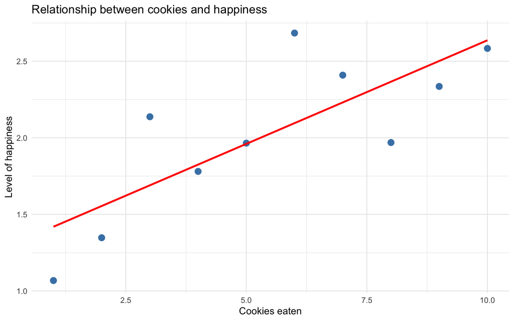

**Interpretation of slope.** A 1-unit increase in `cookies` is associated with a $\beta_1$ change in `happiness`, on average.

## Variable Types

- Numeric (continuous)
- Categorical (factors)

## Life Expectancy and Happiness

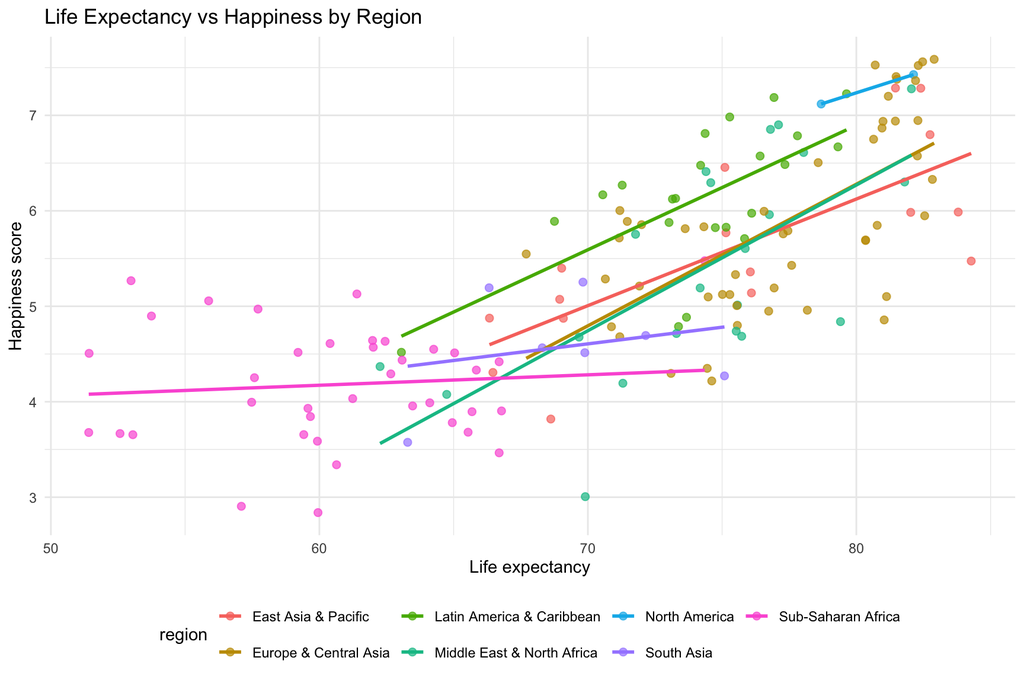

## Regional Differences

| Region | Average Happiness | Number of Countries |
| --- | --- | --- |
| North America | 7.27 | 2 |
| Latin America & Caribbean | 6.14 | 22 |
| Europe & Central Asia | 5.89 | 49 |
| East Asia & Pacific | 5.62 | 16 |
| Middle East & North Africa | 5.40 | 21 |
| South Asia | 4.58 | 7 |
| Sub-Saharan Africa | 4.18 | 38 |

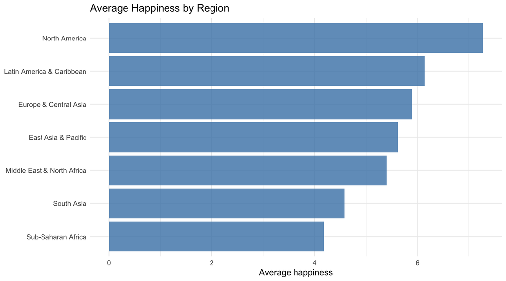

## Model: Happiness ~ Region

| Term | Estimate | Std. Error | t-statistic | p-value | 95% CI Lower | 95% CI Upper |
| --- | --- | --- | --- | --- | --- | --- |
| (Intercept) | 5.618 | 0.217 | 25.841 | 1.008 × 10<sup>−56</sup> | 5.188 | 6.047 |
| region: Europe & Central Asia | 0.271 | 0.250 | 1.084 | 2.801 × 10<sup>−1</sup> | −0.223 | 0.766 |
| region: Latin America & Caribbean | 0.527 | 0.286 | 1.844 | 6.722 × 10<sup>−2</sup> | −0.038 | 1.091 |
| region: Middle East & North Africa | −0.214 | 0.289 | −0.742 | 4.591 × 10<sup>−1</sup> | −0.784 | 0.356 |
| region: North America | 1.655 | 0.652 | 2.538 | 1.219 × 10<sup>−2</sup> | 0.366 | 2.944 |
| region: South Asia | −1.037 | 0.394 | −2.631 | 9.402 × 10<sup>−3</sup> | −1.816 | −0.258 |
| region: Sub-Saharan Africa | −1.437 | 0.259 | −5.544 | 1.319 × 10<sup>−7</sup> | −1.949 | −0.925 |

## Predicted Means by Region (baseline = East Asia & Pacific)

| Region | Predicted Mean Happiness |
| --- | --- |
| North America | 7.273 |
| Latin America & Caribbean | 6.145 |
| Europe & Central Asia | 5.889 |
| East Asia & Pacific | 5.618 |
| Middle East & North Africa | 5.404 |
| South Asia | 4.581 |
| Sub-Saharan Africa | 4.181 |

- Compared to East Asia & Pacific, the coefficient on each region is the mean difference in happiness.

## Multiple Regression

| Term | Estimate | Std. Error | t-statistic | p-value | 95% CI Lower | 95% CI Upper |
| --- | --- | --- | --- | --- | --- | --- |
| (Intercept) | −2.111 | 0.835 | −2.529 | 1.299 × 10<sup>−2</sup> | −3.767 | −0.455 |
| life_expectancy | 0.101 | 0.014 | 7.447 | 3.448 × 10<sup>−11</sup> | 0.074 | 0.128 |
| school_enrollment | 0.003 | 0.010 | 0.331 | 7.410 × 10<sup>−1</sup> | −0.016 | 0.023 |

## R² and Adjusted R²

How much variation in (y) is explained by (x). Scale 0–1. Higher indicates better fit.

## Finding R² in R

| R² | Adjusted R² |
| --- | --- |
| 0.552 | 0.549 |

| R² | Adjusted R² |
| --- | --- |
| 0.492 | 0.482 |

## Interpreting R²

- “This model explains X% of the variation in the outcome.”
- Use (R^2) for one predictor. Use adjusted (R^2) for multiple predictors.
- Higher is better. No universal threshold.